# Biometrie onderzoek

2023-04-26

## Inleiding

Er wordt onderzocht naar een verhouding tussen hand lengte en hand breedte bij mannen en vrouwen. En eventueel andere relaties, door middel van het opmeten van de dominante hand bij verschillende mensen.

De data dat verzameld is voor deze casus is gedaan bij de een voornamelijke leeftijd groep van 17 tot 25. Hierdoor kan de data afwijken in vergelijking met oudere volwassenen

## Onderzoeksvraag

Wat is de relatie tussen de hand breedte en de hand lengte bij de verschillende sekse? :::

## 0-Hypothese

Mannen hebben een grotere verhouding dan vrouwen tussen hand breedte en hand lengte.

## Hypothese

Mannen en vrouwen hebben geen verschil in realtie met hand breedte en hand lengte.

### Ontwerp van het experiment

Meten van de hand bij 20 mannen en vrouwen van verschillende leeftijden met verschillende soorten lichaamsbouw. Om diversiteit zo groot mogelijk te houden.

### Ontwerp het protocol

#### Protocol voor meting handlengte en handbreedte

##### Benodigdheden

1. Maatlat, schuifmaat of meetlint.
2. Spreadsheet om resultaten vast te leggen, met toegang hiertoe op locaties zonder internet-toegang.
3. Je laborant-ID: een unieke *identifier* die jou als onderzoeker identificeert. Neem hiervoor de laatste 4 cijfers van je studentnummer.

##### Data verzamelen

Ga door totdat van voldoende proefpersonen de gegevens zijn verzameld.

## Uitvoering

Je moet de onderzoeksresultaten in deze vorm opslaan:

```
laborant_ID,subject_ID,handlengte,handbreedte,sexe
3241,G1_03,113,104,m
```

## Analyse

### Lees je eigen data in

Om data vanuit een tekstbestand in te lezen kan je dit codeblok gebruiken, aannemend dat je data er exact zo uitzien als in bovenstaande voorbeeld:

```r
data_file <- "../raw_data/data.csv"

#data format: laborant_ID,subject_ID,handlengte,handbreedte,sexe
biometric_data <- read.table(file = data_file,
                        header = TRUE,
                        sep = ";")
```

```r
# get mean of the 2 different data points
biometric_dat <- aggregate(.~id_data ,data=biometric_data[ , c('id_data','lengte', 'breedte')], FUN = mean)
sekse <- biometric_data[20:60, c('sexse')]

formatted_data <- cbind(biometric_dat, sekse)
```

### Beschrijvende statistiek

#### Histogram

Dit is een histogram van alle verkregen data.

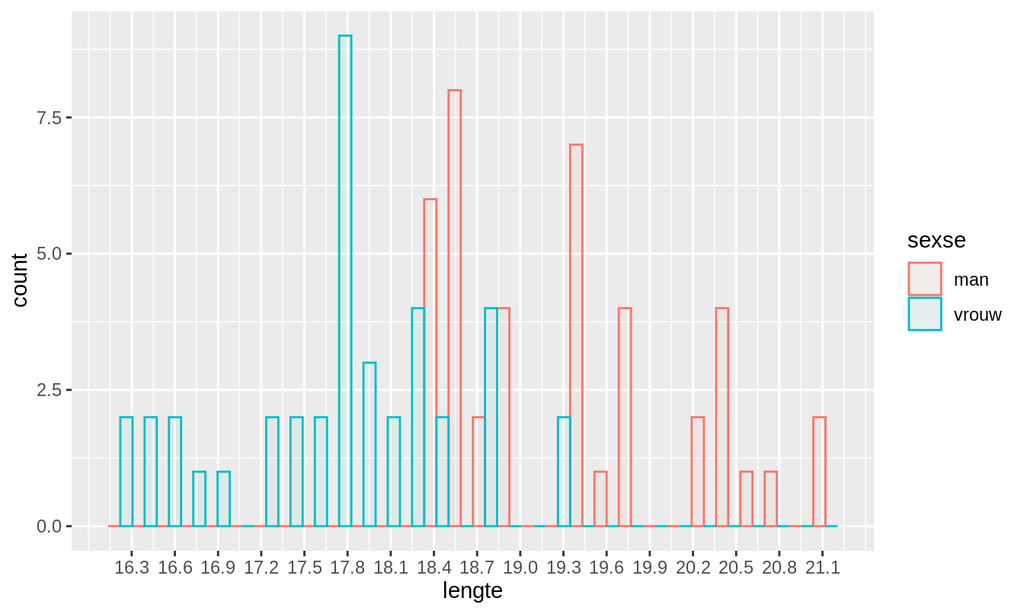

```r
# histogramm van alle data

ggplot(data = biometric_data) +
       geom_histogram(mapping = aes(x = lengte,  fill=sexse, col=sexse, group=sexse), bins = 30, alpha = 0.05, position="dodge", right=TRUE) +
  scale_x_continuous(breaks = seq(min(biometric_data$lengte),
                                  max(biometric_data$lengte), by = 0.3))
```

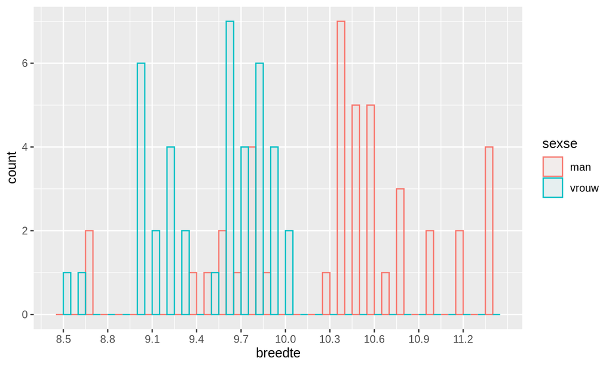

```r
ggplot(data = biometric_data) +
       geom_histogram(mapping = aes(x = breedte,  fill=sexse, col=sexse, group=sexse), bins = 30, alpha = 0.05, position="dodge", right=TRUE) +
  scale_x_continuous(breaks = seq(min(biometric_data$breedte),
                                  max(biometric_data$breedte), by = 0.3))
```

#### Boxplot

Dit is en boxplot van alle verkegen data.

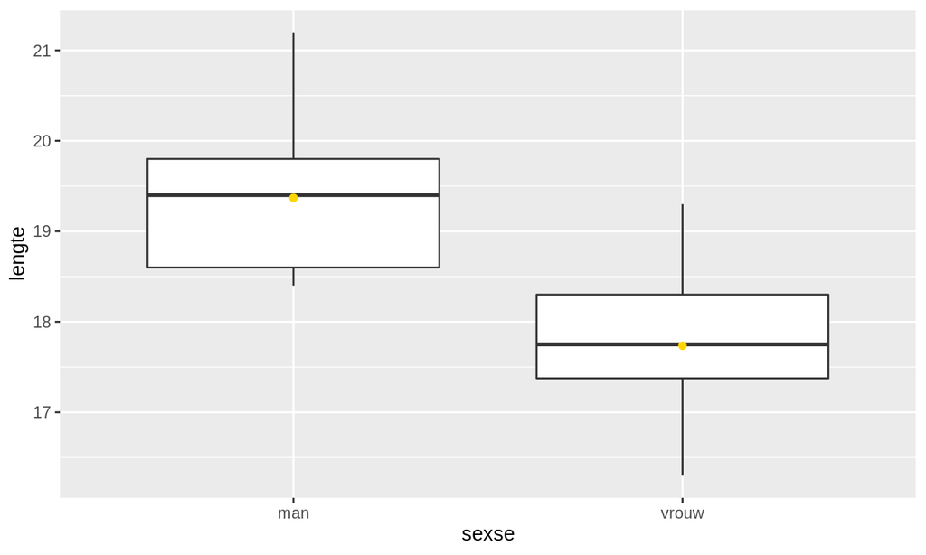

```r
ggplot(data = biometric_data,
       mapping = aes(x = sexse, y = lengte)) +
      geom_boxplot() +
      stat_summary(fun = "mean", geom = "point",
               color = "gold")
```

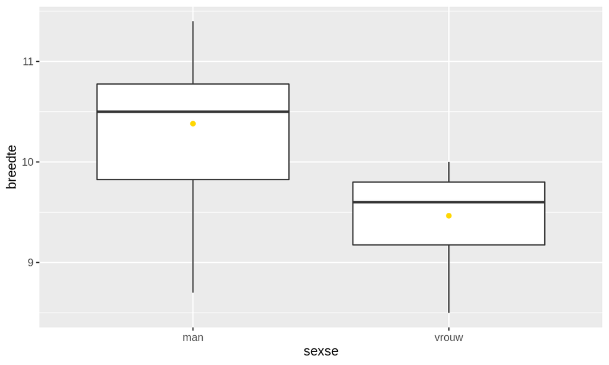

```r
ggplot(data = biometric_data,
       mapping = aes(x = sexse, y = breedte)) +
      geom_boxplot() +
      stat_summary(fun = "mean", geom = "point",
               color = "gold")
```

Hier kan er gezien worden dat de gemiddelde hand lengte en hand breedte hoger liggen bij de man dan bij de vrouw. Ook kan er gezien worden dat de gemiddelde handbreedte hoger ligt in het bereik dan bij alle overige data.

#### Ratio bij hand lengte en hand breedte

Als je de hand lengte deelt door de hand breedte krijg je een ratio. Dit vertelt je hoeveel langer je hand is in vergelijking met je hand breedte.

```r
#determine ratio
breedte_man_mean <- mean((biometric_data[biometric_data$sexse == "man", ])$breedte)
breedte_vrouw_mean <- mean((biometric_data[biometric_data$sexse == "vrouw", ])$breedte)
lengte_man_mean <- mean((biometric_data[biometric_data$sexse == "man", ])$lengte)
lengte_vrouw_mean <- mean((biometric_data[biometric_data$sexse == "vrouw", ])$lengte)
ratio_vrouw <- (lengte_vrouw_mean/breedte_vrouw_mean)
ratio_man <- (lengte_man_mean/breedte_man_mean)

print(paste("De ratio voor man is: ", ratio_man))
```

```
## [1] "De ratio voor man is:  1.86582568807339"
```

```r
print(paste("De ratio voor vrouw is: ", ratio_vrouw))
```

```
## [1] "De ratio voor vrouw is:  1.87374537770734"
```

### Welke verdeling?

1. Wat gebeurt er met de vorm van de verdeling als `n` groter wordt?

De grafiek wordt steeds hoger en stijler in toppen van de verschillende balken.

2. Wat gebeurt er met de spreiding van de data (x-as) als `n` groter wordt, en kan je dat verklaren?

Je hebt meer data punten en hierdoor wordt de data die je hebt verkregen accurater. De stapjes tussen de verschillende punten worden namelijk kleiner. En komt er een steeds een kleiner percentage van alle data in de eerste en laatste 17%.

3. Waarom is bij zelfde instellingen voor `n` en `breaks` de uitkomst toch verschillend?

4. Welke minimale `n` geeft het meeste kans om een echte normaalverdeling te zien?

Bij de 10000 zie je echt een normaalverdeling verschijnen, dit kan je herkennen dat er 2,5% van de grafiek op de eerste en laatst 1/6 deel van de grafiek zit.

5. Wat voor bijzonders is er aan de hand met het `breaks` argument? Geeft de documentatie daar een verklaring voor?

## Reflectie op het experiment

Bespreek in je groep de volgende vragen en voeg de antwoorden toe aan je uitgewerkte onderzoeksdocument.

1. Zijn de metingen tussen de verschillende meters ook (significant) verschillend? Zo ja, waardoor zou je de verschillen kunnen verklaren?

2. Onderzoek de verschillen tussen mannen en vrouwen met betrekking tot hand lengte, handbreedte en de ratio.

3. Zou je het protocol aanpassen na deze ervaring, of was hij voldoende duidelijk en reproduceerbaar?

Het protocool zelf was duidelijk en reproduceerbaar, alleen om data te verzamelen dat meer betrouwbaar is kan er om meer informatie van de persoon worden gevraagd. Zoals lengte, leeftijd en gewicht van de persoon, deze factoren kunnen ook effect hebben op de verhoudingen van de hand van een persoon.